# Tutorial: cross-validation for single cell RNA-seq data via count splitting

In this tutorial, we use simple simulated datasets to show how to use count splitting to do cross-validation for unsupervised learning. Make sure that the packages below are installed, and then proceed with loading the packages.

```r
library(countsplit)
library(tidyverse)
library(Matrix)
library(lemon)
library(patchwork)
```

Note that this tutorial assumes basic familiarity with the methodology described in [our paper](https://arxiv.org/abs/2307.12985).

We start by generating simple data from a negative binomial distribution. The data has three true clusters $(K^*=3)$. We generate data with only two genes ($p=2$) so that we can visualize the clusters more easily. Throughout this document, our goal is to estimate the true number of clusters $K^*$.

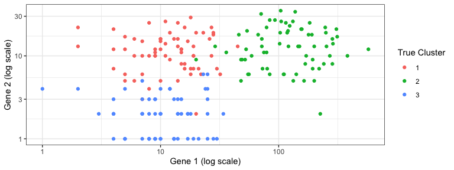

```r
library(tidyverse)
set.seed(1)
n=200
p=2
lambda <- matrix(exp(2.5), nrow=n, ncol=p, byrow = TRUE)
clusters <- sample(1:3, size=n, replace=TRUE)
lambda[clusters==2,1] <-  exp(5)
lambda[clusters==3,2] <-  exp(0.1)
true.overdisps <- c(3,6)
X <- sapply(1:p, function(u) rnbinom(length(lambda[,u]), mu=lambda[,u], size= true.overdisps[u]))
ggplot(data=NULL, aes(x=X[,1]+1, y=X[,2]+1, col=as.factor(clusters)))+
  geom_point()+
  scale_x_log10()+
  scale_y_log10()+
  theme_bw()+
  labs(col="True Cluster")+
  xlab("Gene 1 (log scale)")+ ylab("Gene 2 (log scale)")
```

# Naive method

In order to estimate $K^*$, we try out models with different numbers of clusters $k$ ranging from $1$ to $10$, so as to see which model best fits the observed data. Unfortunately, if we estimate the clusters and evaluate the clusters on the same data, models with more clusters (i.e. more complexity) will always appear better. Thus, our loss function curve decreases monotonically with the number of clusters, and we cannot simply pick the value of $k$ that minimizes the loss function. We demonstrate this issue below.

We will use within-cluster sum of squared errors (SSE) as our loss function. We implement this loss function here. Note that the within-cluster SSE is computed on a log scale.

```r
cluster.sse <- function(trainDat, testDat, clusters.est, eps.train) {
  totSS <- 0
  for (lab in unique(clusters.est)) {
    if (sum(clusters.est==lab) > 1) {
    clustdat.test <- testDat[clusters.est==lab,]
    clustdat.train <- trainDat[clusters.est==lab,]
    colmeansTrain <- colMeans(clustdat.train)
    pred.means <- 1/eps.train*colmeansTrain
    ss <- rowSums((log1p(t(clustdat.test)) - log1p(pred.means))^2)
    totSS <- totSS+sum(ss)
    }
  }
  return(totSS)
}
```

We first consider the naive method, which estimates clusters using all of the data, and then computes the SSE using all of the data. In the context of the function above, this means that `trainDat=testDat=X`.

```r
set.seed(2)
naive.res <- rep(NA, 10)
for (k in 1:10) {
  clusters.est <- kmeans(log(X+1), centers=k)$cluster
  naive.res[k] <- cluster.sse(X,X,clusters.est, 0.5)
}
naive.res
```

```
##  [1] 1263.9885  591.0157  382.8669  338.3161  312.5014  287.4332  279.4420
##  [8]  258.4024  235.5307  234.8612
```

We normalize the SSE results such that they lie between $0$ and $1$. This will later facilitate comparisons between methods. We then ploot the results. As expected, this naive method leads to a within-cluster SSE that decreases monotonically with $k$, and thus leaves no clear strategy for estimating $K^*$.

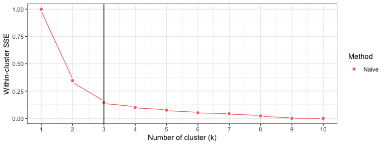

```r
naive.res.norm <- (naive.res - min(naive.res))/(max(naive.res)-min(naive.res))
ggplot(data=NULL)+
  geom_pointline(aes(x=1:10, y=naive.res.norm, col="Naive"))+
  theme_bw()+
  ylab("Within-cluster SSE")+
  xlab("Number of cluster (k)")+
  geom_vline(aes(xintercept=3))+
  labs(col="Method")+
  scale_x_continuous(breaks=0:11)
```

# Count splitting (two folds)

Splitting our data into a training set and a test set can help us avoid this issue.

We first consider Poisson count splitting. We note that, since the data are not actually Poisson distributed, we do not expect Poisson count splitting to solve our problem.

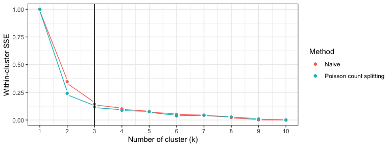

```r
set.seed(5)
poisSplit <- countsplit(X)
Xtrain.pois <- poisSplit[[1]]
Xtest.pois <- poisSplit[[2]]
pois.res <- rep(NA, 10)
for (k in 1:10) {
  clusters.est <- kmeans(log(Xtrain.pois+1), centers=k)$cluster
  pois.res[k] <- cluster.sse(Xtrain.pois,Xtest.pois,clusters.est, 0.5)
}
pois.res.norm <- (pois.res - min(pois.res))/(max(pois.res)-min(pois.res))
ggplot(data=NULL)+
  geom_pointline(aes(x=1:10, y=naive.res.norm, col="Naive"))+
  geom_pointline(aes(x=1:10, y=pois.res.norm, col="Poisson count splitting"))+
  theme_bw()+
  ylab("Within-cluster SSE")+
  xlab("Number of cluster (k)")+
  geom_vline(aes(xintercept=3))+
  labs(col="Method")+
  scale_x_continuous(breaks=0:11)+
  theme_bw()
```

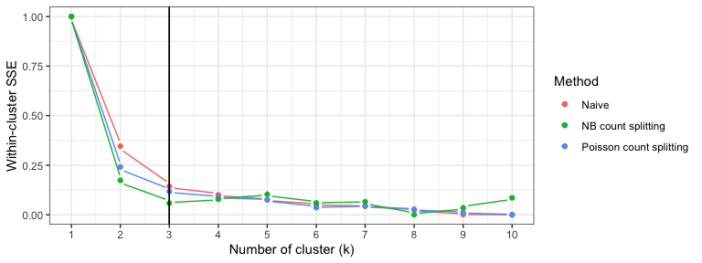

```r
set.seed(3)
knownSplit <- countsplit(X, overdisps=true.overdisps)
Xtrain.known <- knownSplit[[1]]
Xtest.known <- knownSplit[[2]]
known.res <- rep(NA, 10)
for (k in 1:10) {
  clusters.est <- kmeans(log(Xtrain.known+1), centers=k)$cluster
  known.res[k] <- cluster.sse(Xtrain.known,Xtest.known,clusters.est, 0.5)
}
known.res.norm <- (known.res - min(known.res))/(max(known.res)-min(known.res))
ggplot(data=NULL)+
  geom_pointline(aes(x=1:10, y=naive.res.norm, col="Naive"))+
  geom_pointline(aes(x=1:10, y=pois.res.norm, col="Poisson count splitting"))+
  geom_pointline(aes(x=1:10, y=known.res.norm, col="NB count splitting"))+
  geom_vline(xintercept=3)+
  theme_bw()+
  ylab("Within-cluster SSE")+
  xlab("Number of cluster (k)")+
  geom_vline(aes(xintercept=3))+
  labs(col="Method")+
  scale_x_continuous(breaks=0:11)+
  theme(legend.text = element_text(size=10))+
  theme_bw()
```

In reality, we would need to use estimated values for the overdispersion parameters. In this toy setting with only two genes, estimating the overdispersion parameters will be difficult. For large datasets, packages such as `sctransform` obtain reasonable estimates of overdispersion parameters by making use of the fact that most genes tend to be null (not differentially expressed across any cells) and that genes with similar average experssion levels have similar overdispersion parameters. We will explore the matter of estimated overdispersion parameters in future tutorials.

```r
summary(MASS::glm.nb(X[,1]~1))$theta
```

```
## [1] 0.649406
```

```r
summary(MASS::glm.nb(X[,2]~1))$theta
```

```
## [1] 1.008034
```

# Cross validation via count splitting

We can improve on the previous analysis by replacing a single train/test split with cross validation. We do this in the negative binomial setting, as this is the correct setting for this analysis.

We first create five identically distributed folds of data.

```r
set.seed(10)
folds <- 5
partition.known <-  countsplit(X, folds=folds, overdisps=true.overdisps)
```

We know loop through each fold of data. For each fold, we estimate clusters on all the data that are not in that fold, and we evaluate the MSE using the held out fold.

```r
knownRes <- matrix(NA, nrow=folds, ncol=10)
for (fold in 1:folds) {
        testDat <- partition.known[[fold]]
        trainDat <- X - testDat
         for (j in 1:10) {
             clusters.train <- kmeans(log(trainDat+1), centers=j, nstart=10)$cluster
              knownRes[fold,j] <- cluster.sse(trainDat, testDat, clusters.train, 1-1/folds)
         }
}
```

The total score for each attempted number of clusters ($k$) is taken to be the average MSE across the 5 folds. We once again normalize to facilitate comparison with other methods.

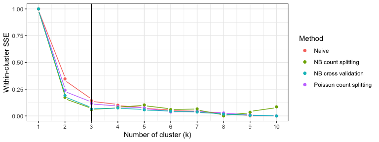

```r
MSEs <- colMeans(knownRes)
MSEs.norm <- (MSEs-min(MSEs))/(max(MSEs)-min(MSEs))
ggplot(data=NULL)+
  geom_pointline(aes(x=1:10, y=naive.res.norm, col="Naive"))+
  geom_pointline(aes(x=1:10, y=pois.res.norm, col="Poisson count splitting"))+
  geom_pointline(aes(x=1:10, y=known.res.norm, col="NB count splitting"))+
  geom_pointline(aes(x=1:10, y=MSEs.norm, col="NB cross validation"))+
  geom_vline(xintercept=3)+
  theme_bw()+
  ylab("Within-cluster SSE")+
  xlab("Number of cluster (k)")+
  geom_vline(aes(xintercept=3))+
  labs(col="Method")+
  scale_x_continuous(breaks=0:11)+
  theme(legend.text = element_text(size=10))+
  theme_bw()
```

# Visualizing what is going on

A nice thing about working with data in two dimensions is that we can visualize our data along with either the true clusters or the estimated clusters. We start by plotting our training set and our test set, with the shape of the points representing the true cluster assignments. We can see that both the training set and the test set are grouped in space according to their true cluster values. Thus, we will be able to get reasonable estimates of the true clusters using the training set, and evaluate these estimates well using the test set.

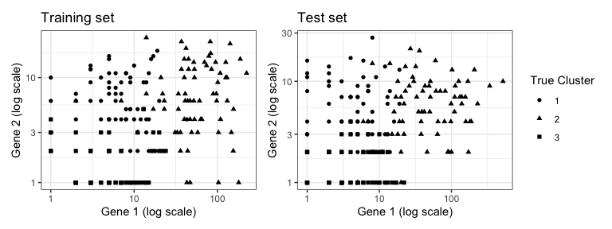

```r
p1 <- ggplot(data=NULL, aes(x=Xtrain.known[,1]+1, y=Xtrain.known[,2]+1, pch=as.factor(clusters)))+
  geom_point()+
  scale_x_log10()+
  scale_y_log10()+
  theme_bw()+
  labs(shape="True Cluster")+
  xlab("Gene 1 (log scale)")+ ylab("Gene 2 (log scale)")+
  ggtitle("Training set")

p2 <- ggplot(data=NULL, aes(x=Xtest.known[,1]+1, y=Xtest.known[,2]+1, pch=as.factor(clusters)))+
  geom_point()+
  scale_x_log10()+
  scale_y_log10()+
  theme_bw()+
  labs(shape="True Cluster")+
  xlab("Gene 1 (log scale)")+ ylab("Gene 2 (log scale)")+
  ggtitle("Test set")

p1+p2+plot_layout(guides="collect")
```

We now move on to estimating clusters. Here, we see that when we estimate $k=3$ clusters on the training set, these cluster labels are still arranged according to location in space on the test set. This is becauase the $k=3$ estimated clusters are capturing true signal (differences in mean) rather than random noise. This true signal exists in both the training set and the test set.

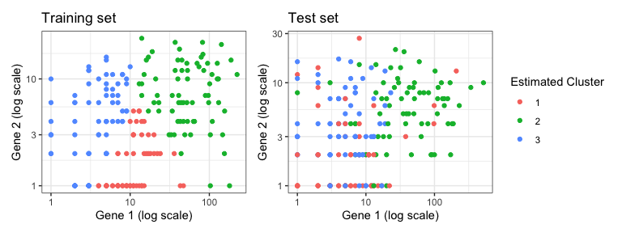

```r
estimated.clusters.3 <- kmeans(log(Xtrain.known+1), 3)$cluster

p3 <- ggplot(data=NULL, aes(x=Xtrain.known[,1]+1, y=Xtrain.known[,2]+1, col=as.factor(estimated.clusters.3)))+
  geom_point()+
  scale_x_log10()+
  scale_y_log10()+
  theme_bw()+
  labs(col="Estimated Cluster")+
  xlab("Gene 1 (log scale)")+ ylab("Gene 2 (log scale)")+
  ggtitle("Training set")

p4 <- ggplot(data=NULL, aes(x=Xtest.known[,1]+1, y=Xtest.known[,2]+1, col=as.factor(estimated.clusters.3)))+
  geom_point()+
  scale_x_log10()+
  scale_y_log10()+
  theme_bw()+
  labs(col="Estimated Cluster")+
  xlab("Gene 1 (log scale)")+ ylab("Gene 2 (log scale)")+
  ggtitle("Test set")

p3+p4+plot_layout(guides="collect")
```

Suppose that we estimate $k=6$ clusters on the training set. While the clusters are distributed according to location in space on the training set, these cluster labels are not well separated in space when applied to the test set. This is because we estimated too many clusters, and so some of the differences seen in the training set were the result of random noise rather than true signal. This will lead to poor performance metrics on the test set, which is what we want, since $k=6$ was an incorrect guess.

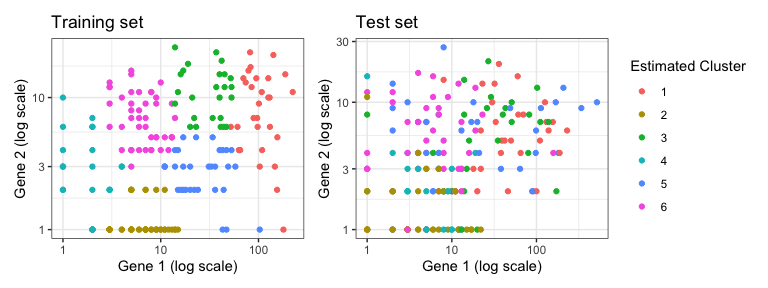

```r
estimated.clusters.6 <- kmeans(log(Xtrain.known+1), 6)$cluster

p5 <- ggplot(data=NULL, aes(x=Xtrain.known[,1]+1, y=Xtrain.known[,2]+1, col=as.factor(estimated.clusters.6)))+
  geom_point()+
  scale_x_log10()+
  scale_y_log10()+
  theme_bw()+
  labs(col="Estimated Cluster")+
  xlab("Gene 1 (log scale)")+ ylab("Gene 2 (log scale)")+
  ggtitle("Training set")

p6 <- ggplot(data=NULL, aes(x=Xtest.known[,1]+1, y=Xtest.known[,2]+1, col=as.factor(estimated.clusters.6)))+
  geom_point()+
  scale_x_log10()+
  scale_y_log10()+
  theme_bw()+
  labs(col="Estimated Cluster")+
  xlab("Gene 1 (log scale)")+ ylab("Gene 2 (log scale)")+
  ggtitle("Test set")

p5+p6+plot_layout(guides="collect")
```

# An alternate validation metric

Rather than evaluate our clusters based on within-cluster mean-squared-error, we can consider evaluating our clusters based on their stability. This idea will work best when the true clusters are well-separated and not nested within each-other.

To gain intuition for this idea, consider the following example dataset. It is similar to the dataset above, but the signal strength is stronger such that the clusters are more well-separated in log-space.

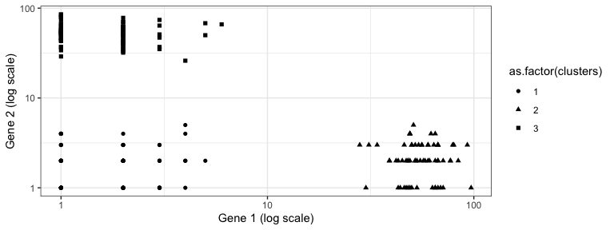

```r
set.seed(111)
n=200
p=2
lambda <- matrix(1, nrow=n, ncol=p)
clusters <- sample(1:3, size=n, replace=TRUE)
lambda[clusters==2,1] <-  lambda[clusters==2,1]*exp(4)
lambda[clusters==3,2] <-  lambda[clusters==3,2]*exp(4)
true.overdisps <- c(20,20)
X <- sapply(1:p, function(u) rnbinom(length(lambda[,u]), mu=lambda[,u], size= true.overdisps[u]))
ggplot(data=NULL, aes(x=X[,1]+1, y=X[,2]+1, pch=as.factor(clusters)))+
  geom_point()+
  theme_bw()+
  scale_x_log10()+
  scale_y_log10()+
  labs(col="True Cluster")+
  xlab("Gene 1 (log scale)")+ ylab("Gene 2 (log scale)")
```

Suppose that we split this data into a training set and a test set. In this section, we will do negative binomial count splitting using the true value of the overdipsersion parameter.

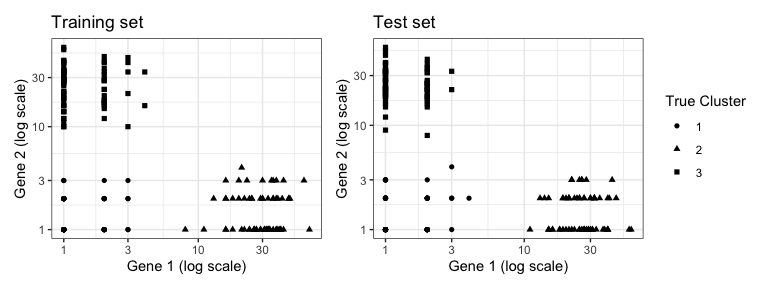

```r
set.seed(222)
knownSplit <- countsplit(X, overdisps=true.overdisps)
Xtrain.known <- knownSplit[[1]]
Xtest.known <- knownSplit[[2]]

p1 <- ggplot(data=NULL, aes(x=Xtrain.known[,1]+1, y=Xtrain.known[,2]+1, pch=as.factor(clusters)))+
  geom_point()+
  scale_x_log10()+
  scale_y_log10()+
  theme_bw()+
  labs(shape="True Cluster")+
  xlab("Gene 1 (log scale)")+ ylab("Gene 2 (log scale)")+
  ggtitle("Training set")

p2 <- ggplot(data=NULL, aes(x=Xtest.known[,1]+1, y=Xtest.known[,2]+1, pch=as.factor(clusters)))+
  geom_point()+
  scale_x_log10()+
  scale_y_log10()+
  theme_bw()+
  labs(shape="True Cluster")+
  xlab("Gene 1 (log scale)")+ ylab("Gene 2 (log scale)")+
  ggtitle("Test set")

p1+p2+plot_layout(guides="collect")
```

The main idea is that, if we estimate three clusters on the training set and also estimate three clusters on the test set, the resulting clusterings should be very similar to one another because they are capturing true signal, not random noise.

```r
set.seed(333)
clusters.est.train <- kmeans(log(Xtrain.known+1), centers=3)$cluster
clusters.est.test <- kmeans(log(Xtest.known+1), centers=3)$cluster
mclust::adjustedRandIndex(clusters.est.train,clusters.est.test)
```

```
## [1] 1
```

```r
set.seed(444)
clusters.est.train <- kmeans(log(Xtrain.known+1), centers=2)$cluster
clusters.est.test <- kmeans(log(Xtest.known+1), centers=2)$cluster
mclust::adjustedRandIndex(clusters.est.train,clusters.est.test)
```

```
## [1] 0.1249398
```

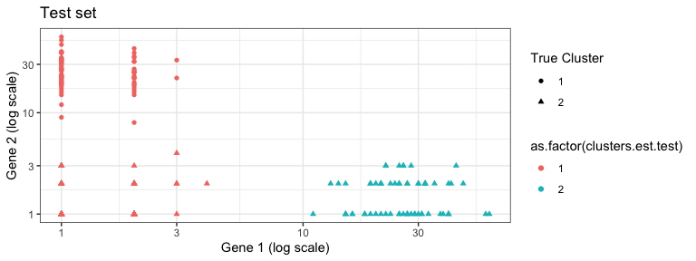

```r
ggplot(data=NULL, aes(x=Xtest.known[,1]+1, y=Xtest.known[,2]+1, pch=as.factor(clusters.est.train),
                      col=as.factor(clusters.est.test)))+
  geom_point()+
  scale_x_log10()+
  scale_y_log10()+
  theme_bw()+
  labs(shape="True Cluster")+
  xlab("Gene 1 (log scale)")+ ylab("Gene 2 (log scale)")+
  ggtitle("Test set")
```

```r
set.seed(5)
clusters.est.train <- kmeans(log(Xtrain.known+1), centers=5)$cluster
clusters.est.test <- kmeans(log(Xtest.known+1), centers=5)$cluster
mclust::adjustedRandIndex(clusters.est.train,clusters.est.test)
```

```
## [1] 0.513996
```

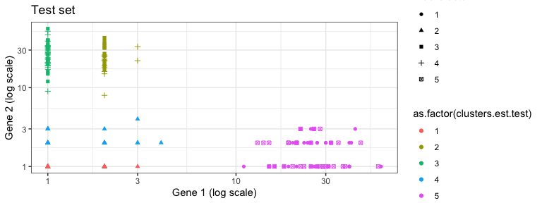

```r
ggplot(data=NULL, aes(x=Xtest.known[,1]+1, y=Xtest.known[,2]+1, pch=as.factor(clusters.est.train),
                      col=as.factor(clusters.est.test)))+
  geom_point()+
  scale_x_log10()+
  scale_y_log10()+
  theme_bw()+
  labs(shape="True Cluster")+
  xlab("Gene 1 (log scale)")+ ylab("Gene 2 (log scale)")+
  ggtitle("Test set")
```

The principle is simple: if we are estimating the correct number of clusters, our clusterings should be similar whether we estimate them on the training set or the test set.

We use the same data that we generated above.

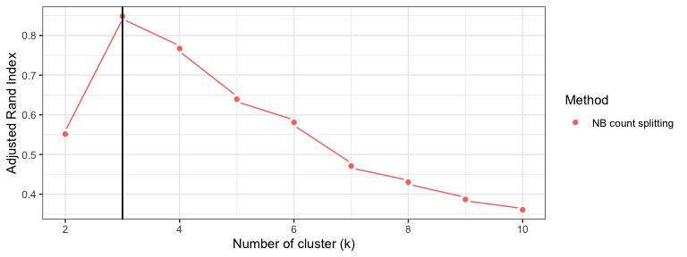

```r
stability.res <- matrix(NA, nrow=100, ncol=9)

for (t in 1:100) {
  set.seed(t)
  knownSplit <- countsplit(X, overdisps=true.overdisps)
  Xtrain.known <- knownSplit[[1]]
  Xtest.known <- knownSplit[[2]]

  for (k in 2:10) {
    clusters.est.train <- kmeans(log(Xtrain.known+1), centers=k)$cluster
    clusters.est.test <- kmeans(log(Xtest.known+1), centers=k)$cluster
    stability.res[t,k-1] <- mclust::adjustedRandIndex(clusters.est.train,clusters.est.test)
  }
}
ggplot(data=NULL)+
  geom_pointline(aes(x=2:10, y=colMeans(stability.res), col="NB count splitting"))+
  geom_vline(xintercept=3)+
  theme_bw()+
  ylab("Adjusted Rand Index")+
  xlab("Number of cluster (k)")+
  geom_vline(aes(xintercept=3))+
  labs(col="Method")+
  theme(legend.text = element_text(size=10))+
  theme_bw()
```

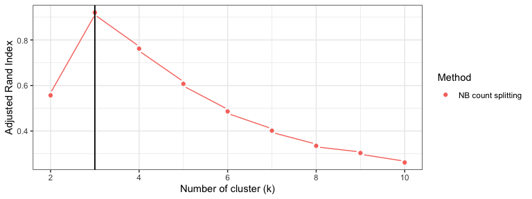

```r
n=1000
p=1000
lambda <- matrix(exp(rnorm(p)), nrow=n, ncol=p, byrow = TRUE)
clusters <- sample(1:3, size=n, replace=TRUE)
lambda[clusters==2,1:20] <-  lambda[clusters==2,1:20]*exp(2)
lambda[clusters==3,11:20] <-  lambda[clusters==3,11:20]*exp(2)
true.overdisps <- colMeans(lambda)
X <- sapply(1:p, function(u) rnbinom(length(lambda[,u]), mu=lambda[,u], size= true.overdisps[u]))

stability.res <- matrix(NA, nrow=100, ncol=9)

for (t in 1:100) {
  set.seed(t)
  knownSplit <- countsplit(X, overdisps=true.overdisps)
  Xtrain.known <- knownSplit[[1]]
  Xtest.known <- knownSplit[[2]]

  for (k in 2:10) {
    clusters.est.train <- kmeans(log(Xtrain.known+1), centers=k)$cluster
    clusters.est.test <- kmeans(log(Xtest.known+1), centers=k)$cluster
    stability.res[t,k-1] <- mclust::adjustedRandIndex(clusters.est.train,clusters.est.test)
  }
}
ggplot(data=NULL)+
  geom_pointline(aes(x=2:10, y=colMeans(stability.res), col="NB count splitting"))+
  geom_vline(xintercept=3)+
  theme_bw()+
  ylab("Adjusted Rand Index")+
  xlab("Number of cluster (k)")+
  geom_vline(aes(xintercept=3))+
  labs(col="Method")+
  theme(legend.text = element_text(size=10))+
  theme_bw()
```